# Waste and Pollution in an Era of Excess

What factors are tied to rising plastic waste?

Author

Siddharth Venkiteswaran

## Why is this important?

Plastic waste pollution has been a problem that has plagued the world for some time, with the magnitude of the problem continuing to grow over the years as efforts to keep waste levels in check have mostly been minimal at best. The amount of waste continues to be a looming threat to the health of many different ecosystems, and this will only continue to get worse for future generations. To better understand this problem, we must better examine the sources of where all this pollution comes from, and understand what exactly rising levels of plastic waste are correlated with. By doing so, we can leverage these relationships to better address the problem of rising levels of waste, and provide a more stable setup for cleanup efforts into the future.

The main item that motivated this data exploration was the relationship of plastic waste with different countries across the globe. Different parts of the globe are subject to different situations, so evidently their relationship with the problem of plastic waste would be different. Two questions came up that appeared to warrant a deeper investigation.

The first question was in regards to the relationship between a country and a corporation when it came to plastic waste. What companies and countries have the highest number of total plastics thrown out over these two years? And were the top countries in plastic waste tied with specific companies that managed to produce products that were responsible for such high levels of pollution?

The second question was more specifically directed towards the countries around the globe. Different countries reside in different levels of economic status, some are richer than others and have a larger footprint in the global economy. Do these richer countries tend to contribute more to plastic waste levels due to their larger economic footprint? Or is the majority of plastic waste concentrated within areas of the world that are considered to be developing regions? One would assume that a country that has a large production output, would also have a large waste output too, and the idea of figuring out if this was true or not was one that motivated this data exploration.

## Understanding the data sets at hand

There were two data sets that were chosen to carry out this investigation.

The first data set comes from a publication on Github, which sourced data from the organization, Break Free From Plastic. Break Free From Plastic is an organization that produces audits on the efforts to clean up plastic pollution within different countries throughout the world. The data set on Github contains data from the 2019 and 2020 audits. With data on different countries around the world in regards to plastic waste, this appeared to be a data set that was relevant to the questions that motivated this exploration.

The plastic data was collected with each count of a specific type of plastic, originating from a combination of a specific country and company. This corresponded to a single observational unit in the data. Counts of these plastics were tallied up to create an aggregate of over 50 countries in the data set. The plastics specifically were classified by recycling codes.

From Break Free From Plastic’s website, the data that was present in the Github publication was collected through tallies of clean up efforts across these different countries. This data was gathered to get information on the sources of plastic pollution, in order to demand a reduction in such waste across the globe, as part of Break Free From Plastic’s mission.

Overall the main variables from this data set were:

- Country of which the plastic was collected in
- Year of collection (2019 or 2020)
- Company responsible for creating the plastic waste
- Grand total of plastics from a country and company combination

The second data set was a GDP data set in regards to specific countries, that was published by the website API Ninjas. Per API Ninjas’ website, the data that is provided on their website comes from various different sources, but API Ninjas does not offer much transparency in who specifically gathered the data that is available in the GDP API endpoint. For the GDP endpoint, much of the data goes back to 1980, with the most recent data going up till 2026.

Data was collected with each country being treated as an observational unit. This data follows the nature of a time series, with data being collected back almost 40 to 50 years in the past for each observational unit.

API Ninjas does not offer much transparency in their methods of data collection, only that they gather what is already collected from different sources and compile it together into their API endpoints. Additionally, from the website, there was no information provided on why this data was gathered, only that the data was collected with the aim of comparing GDP data from one country with others.

The key information that was present in this data set was:

- ISO3 country code
- Year of observation (2019 or 2020)
- GDP value per capita (nominal) in US dollars
- GDP growth rate as a percentage

With these data sets present, the data exploration began by starting off with looking at the relationship between a country and a corporation in regards to plastic waste, before carrying out a country level analysis on how the GDP per capita of a country corresponded to plastic waste.

```r
library(tidyverse)
library(glue)
library(httr)
library(tidyjson)
library(jsonlite)
library(readr)
library(ggalluvial)
library(ggrepel)
library(paletteer)
library(countrycode)
library(gt)
library(broom)
```

```r
## Read in the plastics data
plastics <- readr::read_csv('https://raw.githubusercontent.com/rfordatascience/tidytuesday/main/data/2021/2021-01-26/plastics.csv')
```

```r
## Custom function to get the total number of plastics for each country
total_plastics <- function(input_country){

  grand_total_plastics <- plastics |>
    filter(country == input_country) |>
    distinct(year, grand_total) |>
    pull(grand_total)

  sum(grand_total_plastics, na.rm = TRUE)
}

## Custom function to get total number of plastics for each company
company_total <- function(input_company) {

  company_grand_total <- plastics |>
    filter(parent_company == input_company) |>
    distinct(year, grand_total) |>
    pull(grand_total)

  sum(company_grand_total, na.rm = TRUE)

}

## Custom function for outputting average gdp and plastic total
gdp_plastics <- function(input_country){

  country_data <- plastics_top |>
    filter(country == input_country) |>
    distinct(year, grand_total, gdp_per_capita_nominal)

  tibble(
    plastic_total = sum(country_data$grand_total, na.rm = TRUE),
    avg_gdp_per_capita_nominal = mean(country_data$gdp_per_capita_nominal, na.rm = TRUE)
  )
}
```

```r
get_gdp <- function(country_code, key = my_key) {
  url <- glue("https://api.api-ninjas.com/v1/gdp?country={country_code};X-Api-Key={key}")

  my_data <- safely(fromJSON)(url)

  if (is.null(my_data$result)) {
    return(NA)
  } else {
    return(my_data$result |> filter(year %in% c(2019, 2020)))
  }
}
```

```r
## Create a list of the top 10 countries with the highest total plastics
top_plastic_countries <- plastics |>
  distinct(country) |>
  filter(!country %in% c("EMPTY", "Taiwan_ Republic of China (ROC)")) |>  ## Dropping Taiwan because of its contested status in the world (some supplemental data does not include Taiwan)
  mutate(
    plastic_total = map_int(country, total_plastics),
    country_code = countrycode(country, origin = "country.name", destination = "iso3c")
  ) |>
  filter(!is.na(country_code)) |> ## Dropping Nigeria's duplicate
  filter(plastic_total != 61123) |> ## Added security for removing the specific duplicate
  slice_max(plastic_total, n = 50) |>
  pull(country_code)
```

```r
Sys.sleep(20)
## Create a list of the countries with their GDP
gdp_list <- top_plastic_countries |>
  map(get_gdp)
```

```r
## Turn this into a tibble to join with our original data frame
gdp_data <- gdp_list |>
  keep(is.data.frame) |>
  bind_rows() |>
  rename(country_code = country)

gdp_data |>
  pull(country_code)

## Saving the csv locally
write.csv(gdp_data, "gdp.csv", row.names = FALSE)
```

```r
## Rereading in the data from the local file
gdp_df <- read.csv("gdp.csv")
```

```r
plastics_top <- plastics |>
  filter(!country %in% c("EMPTY",
                         "Nigeria",
                         "Taiwan_ Republic of China (ROC)",
                         "United Kingdom")) |>
  mutate(
    country_code = countrycode(country, origin = "country.name", destination = "iso3c")
  ) |>
  filter(country_code %in% top_plastic_countries) |>
  left_join(gdp_df)
```

## Coca Cola is responsible for a large amount of waste

```r
company_summary <- plastics |>
  distinct(parent_company) |>
  filter(!is.na(parent_company),
         parent_company != "Grand Total",
         parent_company != "null",
         parent_company != "NULL",
         parent_company != "Unbranded") |>
  mutate(
    total_plastic_waste = map_int(parent_company, company_total),
    share_of_total = total_plastic_waste / sum(total_plastic_waste, na.rm = TRUE)
  ) |>
  slice_max(total_plastic_waste, n = 10)

company_summary |>
  gt() |>
  tab_header(
    title = "Company Contribution to Plastic Waste"
  ) |>
  tab_style(
    style = cell_text(weight = "bold"),
    locations = cells_title()
  ) |>
  cols_label(
    parent_company = "Parent Company",
    total_plastic_waste = "Total Waste",
    share_of_total = "Share of Total"
  ) |>
  fmt_percent(
    columns = share_of_total,
    decimals = 3
  ) |>
  fmt_number(columns = total_plastic_waste,
             decimals = 0) |>
  tab_caption("Table 1: Amount of Plastic Waste Attributed to Each Company") |>
  tab_spanner(
    label = "Plastic Counts",
    columns = c(total_plastic_waste, share_of_total)
  )
```

Table 1: Amount of Plastic Waste Attributed to Each Company

Company Contribution to Plastic Waste

| Parent Company | Plastic Counts Total Waste | Plastic Counts Share of Total |
| --- | --- | --- |
| The Coca-Cola Company | 25,483 | 8.328% |
| La Doo | 15,221 | 4.974% |
| Universal Robina Corporation | 8,648 | 2.826% |
| Nestle | 8,607 | 2.813% |
| Unilever | 8,522 | 2.785% |
| Colgate-Palmolive | 6,494 | 2.122% |
| Barna | 6,225 | 2.034% |
| Assorted | 6,101 | 1.994% |
| Pure Water, Inc. | 5,347 | 1.747% |
| Pepsico | 4,965 | 1.623% |

The Coca-Cola Company leads the counts of plastic waste by a comfortable margin, having over 10,000 more items of plastic waste compared to the company La Doo, which has a clear grip on second place. After those two companies, the amount of plastic waste is very close among these different companies, indicating that perhaps the top two companies could be outliers in comparison to the other corporations.

## Two countries carry extreme amounts of plastic waste

```r
## Uses iteration and a custom function
plastics |>
  distinct(country) |>
  filter(!country %in% c("EMPTY", "Taiwan_ Republic of China (ROC)", "Nigeria")) |>
  mutate(
    plastic_total = map_int(country, total_plastics),
    country = recode(country, "NIGERIA" = "Nigeria", "ECUADOR" = "Ecuador"),
    share_of_total = plastic_total / sum(plastic_total, na.rm = TRUE)
    ) |>
  slice_max(plastic_total, n = 10) |>
  gt() |>
  tab_header(
    title = "Countries with the Most Plastic Waste"
  ) |>
  tab_style(
    style = cell_text(weight = "bold"),
    locations = cells_title()
  ) |>
  cols_label(
    country = "Country",
    plastic_total = "Total Waste",
    share_of_total = "Share of Total"
  ) |>
  tab_caption("Table 2: Amount of Plastic Waste From Each Country") |>
  tab_footnote(
    footnote = "Taiwan and Republic of China were removed from data set due to the contested nature of the region. Additionally, duplicates were removed by choosing to keep the entry with higher values for plastic waste.",
    locations = cells_column_labels(
      columns = country
    )
  ) |>
  fmt_number(columns = plastic_total,
             decimals = 0) |>
  fmt_percent(
    columns = share_of_total,
    decimals = 3
  ) |>
  tab_spanner(
    label = "Plastic Counts",
    columns = c(plastic_total, share_of_total)
  )
```

Table 2: Amount of Plastic Waste From Each Country

Countries with the Most Plastic Waste

| Country<sup>1</sup> | Plastic Counts Total Waste | Plastic Counts Share of Total |
| --- | --- | --- |
| Nigeria | 157,133 | 21.036% |
| Philippines | 125,667 | 16.823% |
| Switzerland | 66,588 | 8.914% |
| Indonesia | 34,173 | 4.575% |
| Vietnam | 28,347 | 3.795% |
| Kenya | 27,426 | 3.672% |
| Ecuador | 25,346 | 3.393% |
| United States of America | 21,158 | 2.832% |
| Burkina Faso | 20,348 | 2.724% |
| India | 19,655 | 2.631% |

<sup>1</sup> Taiwan and Republic of China were removed from data set due to the contested nature of the region. Additionally, duplicates were removed by choosing to keep the entry with higher values for plastic waste.

The top country in terms of plastic waste is Nigeria, followed by the Philippines. In a similar trend to what was apparent from Table 1, the top two in this table seem to be outliers in comparison to the rest of the world, as they are the only countries with plastic waste counts above 100,000. The rest of the world seems to be more closely clustered with each other in terms of amount of plastic waste.

## Which companies and countries have the most waste?

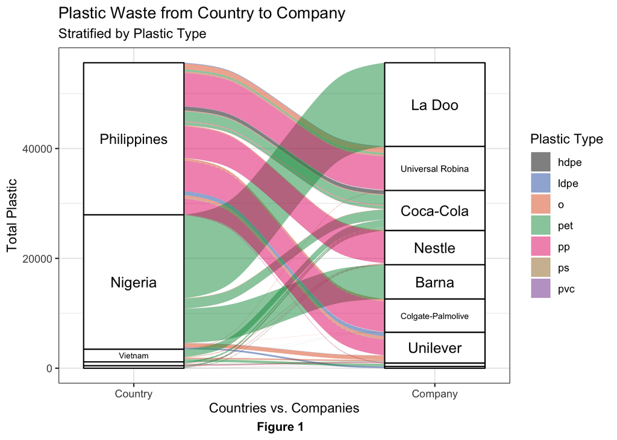

```r
## Get a list of the top 10 companies and the top 5 countries in plastic waste
top10_companies <- unique(company_summary$parent_company)
top5_codes <- top_plastic_countries[1:5]

## Convert the data into the long format
plastics_long <- plastics_top |>
  filter(parent_company %in% top10_companies,
         country_code %in% top5_codes) |>
  select(country, year, parent_company, hdpe, ldpe, o, pet, pp, ps, pvc) |>
  pivot_longer(
    cols = c(hdpe, ldpe, o, pet, pp, ps, pvc),
    names_to = "plastic_type",
    values_to = "total_plastic"
  ) |>
  filter(total_plastic > 0)

## Create the Sankey diagram
plastics_long |>
  mutate(
    country = fct_reorder(country,
                          total_plastic,
                          sum,
                          .desc = TRUE),
    parent_company = fct_reorder(parent_company,
                                 total_plastic,
                                 sum,
                                 .desc = TRUE),
    parent_company = recode(parent_company,
    "Universal Robina Corporation" = "Universal Robina",
    "The Coca-Cola Company" = "Coca-Cola"),
    country = recode(country,
                     "NIGERIA" = "Nigeria")
  ) |>
  ggplot(aes(axis1 = country,
             axis2 = parent_company,
             y = total_plastic)) +
  scale_x_discrete(limits = c("Country", "Company"),
                   expand = c(.2, .05)) +
  geom_alluvium(aes(fill = plastic_type)) +
  geom_stratum() +
  ggfittext::geom_fit_text(stat = "stratum",
                           aes(label = after_stat(stratum)),
                           width = 1/4,
                           min.size = 3) +
  theme_bw() +
  scale_fill_paletteer_d("ggthemes::few_Dark") +
  xlab("Countries vs. Companies") +
  ylab("Total Plastic") +
  ggtitle("Plastic Waste from Country to Company",
          "Stratified by Plastic Type") +
  labs(fill = "Plastic Type",
       caption = "Figure 1") +
  theme(plot.caption.position = "plot",
        plot.caption = element_text(hjust = 0.45,
                                    size = 10,
                                    face = "bold"))
```

Figure 1 above shows the relationship between a country and a company. The countries were limited to the top 5 countries in plastic waste so that the plot could be more easily viewed, while the number of companies is limited to the top 10. From the plot, it is clear that Nigeria is closely tied to La Doo, while the Philippines is more spread out in terms of which corporations contribute to its plastic waste. Additionally, while Coca Cola had the greatest overall total of plastic waste out of all of the companies, within the top 5 countries in plastic waste, it ranks a bit lower, which indicates that the plastic waste that it is responsible for is spread out over a much larger set of countries, rather than just being concentrated in one.

## Top companies appear to “spread the wealth”

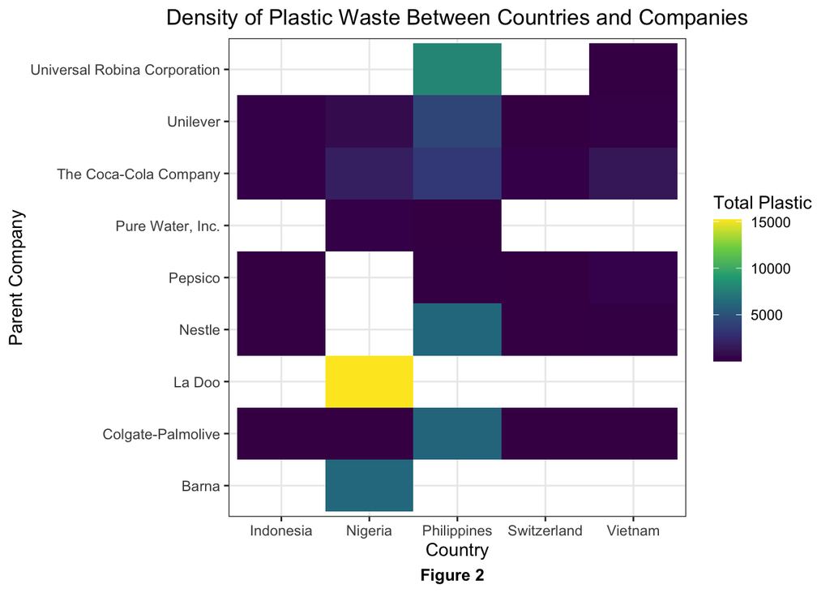

```r
heatmap_data <- plastics_top |>
  filter(
    !is.na(parent_company),
    !country %in% c("EMPTY", "Taiwan_ Republic of China (ROC)", "Nigeria"),
    parent_company != "Grand Total",
    parent_company != "null",
    parent_company != "NULL",
    parent_company != "Unbranded"
  ) |>
  group_by(country, parent_company, country_code) |>
  summarize(plastic_total = sum(grand_total, na.rm = TRUE), .groups = "drop")

heatmap_data |>
  filter(country_code %in% top5_codes, parent_company %in% top10_companies) |>
  mutate(country = recode(country,
                          "NIGERIA" = "Nigeria")) |>
  ggplot(aes(x = country, y = parent_company, fill = plastic_total)) +
  geom_tile() +
  labs(title = "Density of Plastic Waste Between Countries and Companies",
       x = "Country",
       y = "Parent Company",
       fill = "Total Plastic",
       caption = "Figure 2") +
  theme_bw() +
  scale_fill_viridis_c() +
  theme(plot.title = element_text(hjust = 0.5),
        plot.caption.position = "plot",
        plot.caption = element_text(hjust = 0.55,
                                    size = 10,
                                    face = "bold"))
```

Figure 2 complements the findings from Figure 1, as it shows again how Nigeria is very closely tied with the company of La Doo, while showing the rest of the corporations do not hold any such relationship with any other countries. The only country that seems to have a close relationship with a corporation, like Nigeria does with La Doo, is the Philippines with the Universal Robina Corporation. But even with that relationship, the Philippines plastic waste is influenced by a variety of different companies, not just one. This seems to be the case for the rest of the corporations in the top 10, as many seem to hit multiple different areas of Figure 2, rather than just one.

## How rich are countries in the top 10 of plastic waste?

```r
plastics_top |>
  distinct(country) |>
  filter(!country %in% c("EMPTY", "Taiwan_ Republic of China (ROC)", "Nigeria")) |>
  mutate(
    result = map(country, gdp_plastics),
    country = recode(country, "NIGERIA" = "Nigeria", "ECUADOR" = "Ecuador")
  ) |>
  unnest(result) |>
  slice_max(plastic_total, n = 10) |>
  gt() |>
  tab_header(
    title = "Comparing Average GDP with Plastic Waste"
  ) |>
  tab_style(
    style = cell_text(weight = "bold"),
    locations = cells_title()
  ) |>
  cols_label(
    country = "Country",
    plastic_total = "Total Waste",
    avg_gdp_per_capita_nominal = "GDP Per Capita (Average)"
  ) |>
  tab_caption("Table 3: Average GDP Compared to Plastic Waste From Each Country") |>
  tab_spanner(
    label = "Country Statistics",
    columns = c(plastic_total, avg_gdp_per_capita_nominal)
  ) |>
  fmt_currency(columns = avg_gdp_per_capita_nominal,
             decimals = 2) |>
  tab_footnote(
    footnote = "Expressed in billions of USD",
    locations = cells_column_labels(
      columns = avg_gdp_per_capita_nominal
    )) |>
  fmt_number(columns = plastic_total,
             decimals = 0)
```

Table 3: Average GDP Compared to Plastic Waste From Each Country

Comparing Average GDP with Plastic Waste

| Country | Country Statistics Total Waste | Country Statistics GDP Per Capita (Average)<sup>1</sup> |
| --- | --- | --- |
| Nigeria | 157,133 | $2,361.11 |
| Philippines | 125,667 | $3,420.78 |
| Switzerland | 66,588 | $85,415.45 |
| Indonesia | 34,173 | $4,073.83 |
| Vietnam | 28,347 | $3,481.33 |
| Kenya | 27,426 | $2,091.74 |
| Ecuador | 25,346 | $6,199.03 |
| United States of America | 21,158 | $64,798.00 |
| Burkina Faso | 20,348 | $786.91 |
| India | 19,655 | $1,965.00 |

From Table 3, most of the countries in the top 10 of plastic waste have low average GDP per capita numbers, with the United States and Switzerland being the main outliers here. This would initially disprove the intuitive belief that countries with a higher gross domestic output, meaning they produce more, do not contribute high levels of waste compared to countries with a lower average GDP per capita.

## Comparing rankings

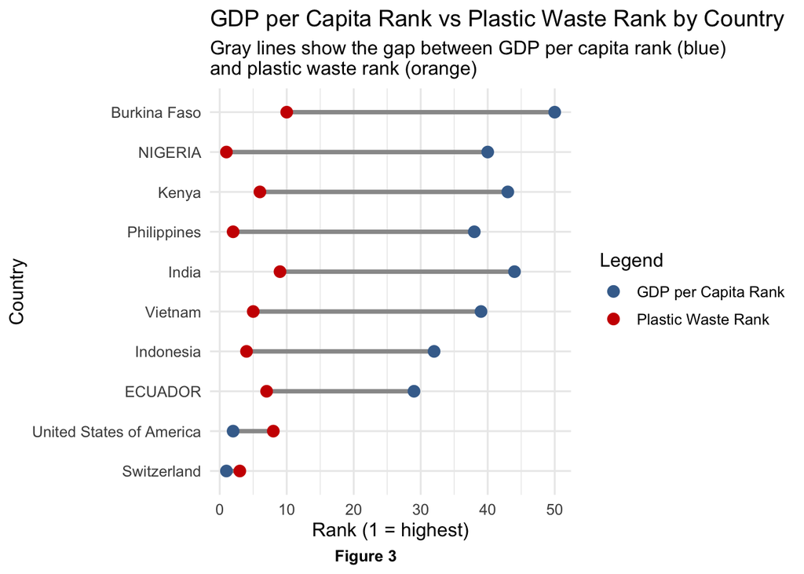

```r
rq2_dumbbell <- plastics_top %>%
  filter(!is.na(gdp_per_capita_nominal), !is.na(grand_total)) %>%
  group_by(country) %>%
  summarize(
    total_plastic = sum(grand_total, na.rm = TRUE),
    avg_gdp_per_capita = mean(gdp_per_capita_nominal, na.rm = TRUE),
    .groups = "drop"
  ) %>%
  mutate(
    gdp_rank = min_rank(desc(avg_gdp_per_capita)),
    plastic_rank = min_rank(desc(total_plastic)),
    rank_gap = abs(gdp_rank - plastic_rank)
  ) %>%
  slice_max(total_plastic, n = 10) %>%
  mutate(country = fct_reorder(country, rank_gap))

ggplot(rq2_dumbbell) +
  geom_segment(
    aes(
      y = country, yend = country,
      x = gdp_rank, xend = plastic_rank
    ),
    color = "gray60",
    linewidth = 1.3
  ) +
  geom_point(
    aes(x = gdp_rank, y = country, color = "GDP per Capita Rank"),
    size = 3
  ) +
  geom_point(
    aes(x = plastic_rank, y = country, color = "Plastic Waste Rank"),
    size = 3
  ) +
  scale_color_manual(
    name = "Legend",
    values = c(
      "GDP per Capita Rank" = "#446E9B",
      "Plastic Waste Rank" = "#CD0200"
    )
  ) +
  labs(
    title = "GDP per Capita Rank vs Plastic Waste Rank by Country",
    subtitle = "Gray lines show the gap between GDP per capita rank (blue)\nand plastic waste rank (orange)",
    x = "Rank (1 = highest)",
    y = "Country",
    caption = "Figure 3"
  ) +
  theme_minimal(base_size = 12) +
  theme(plot.caption.position = "plot",
        plot.caption = element_text(hjust = 0.45,
                                    size = 10,
                                    face = "bold"))
```

With a dedicated visual of showing how the rankings compare between a country’s GDP and their rank in plastic waste, Figure 3 complements the initial findings of Table 3, showing that the countries that are ranked in the top 10 of plastic waste are also ranked near the bottom 30 in terms of average GDP per capita, with only the United States and Switzerland breaking with the trend and having a higher average GDP per capita rank compared to their plastic waste rank. However, more exploration needs to be done to see exactly how the numbers stack up between countries with different GDP levels and their plastic waste.

## Countries with low GDP per capita have more waste

```r
## Modify the plastics data to get 3 quantiles and classifications
quantile_data <- plastics_top |>
  distinct(country, year, grand_total, gdp_per_capita_nominal) |>
  mutate(
    gdp_quantile = case_when(
      gdp_per_capita_nominal <= quantile(gdp_per_capita_nominal,
                                         0.33,
                                         na.rm = TRUE) ~ "Low GDP",
      gdp_per_capita_nominal <= quantile(gdp_per_capita_nominal,
                                         0.66,
                                         na.rm = TRUE) ~ "Mid GDP",
      TRUE ~ "High GDP"
    ),
    gdp_quantile = factor(gdp_quantile,
                          levels = c("Low GDP", "Mid GDP", "High GDP"))
  )

## Create functions to get the total plastic waste and the average gdp per capita
quantile_plastic <- function(input_quantile) {

  total <- quantile_data |>
    filter(gdp_quantile == input_quantile) |>
    pull(grand_total)

  sum(total, na.rm = TRUE)
}

quantile_gdp <- function(input_quantile) {

  avg_gdp_by_country <- quantile_data |>
    filter(gdp_quantile == input_quantile) |>
    group_by(country) |>
    summarise(avg_gdp = mean(gdp_per_capita_nominal, na.rm = TRUE), .groups = "drop") |>
    pull(avg_gdp)

  mean(avg_gdp_by_country, na.rm = TRUE)
}

## Iterate and modify the table
tibble(gdp_quantile = c("Low GDP", "Mid GDP", "High GDP")) |>
  mutate(
    total_plastic = map_int(gdp_quantile, quantile_plastic),
    avg_gdp_per_capita_nominal = map_dbl(gdp_quantile, quantile_gdp),
    share_of_total  = total_plastic / sum(total_plastic, na.rm = TRUE)
  ) |>
  gt() |>
  tab_header(
    title = "Plastic Waste by GDP Categories"
  ) |>
  tab_style(
    style = cell_text(weight = "bold"),
    locations = cells_title()
  ) |>
  cols_label(
    gdp_quantile = "GDP Category",
    total_plastic = "Total Plastic",
    avg_gdp_per_capita_nominal = "GDP Per Capita (Average)",
    share_of_total = "Share of Total"
  ) |>
  tab_caption("Table 4: Plastic Waste Attributed to Different GDP Levels") |>
  tab_spanner(
    label = "GDP Statistics",
    columns = c(avg_gdp_per_capita_nominal, share_of_total)) |>
  tab_footnote(
    footnote = "Expressed in billions of USD",
    locations = cells_column_labels(
      columns = avg_gdp_per_capita_nominal
    )) |>
  fmt_currency(columns = avg_gdp_per_capita_nominal,
             decimals = 2) |>
  fmt_number(columns = total_plastic,
             decimals = 0) |>
  fmt_percent(columns = share_of_total,
              decimals = 3) |>
  tab_footnote(
    footnote = "GDP categories were determined by obtaining the 33rd and 67th percentiles, then designating 'Low GDP' as what lay from the bottom to the 33rd percentile, 'Mid GDP' as what lay from the 33rd to the 67th percentile, and 'High GDP' as what lay from the 67th percentile to the top.",
    locations = cells_column_labels(
      columns = total_plastic
    ))
```

Table 4: Plastic Waste Attributed to Different GDP Levels

Plastic Waste by GDP Categories

| GDP Category | Total Plastic<sup>1</sup> | GDP Statistics GDP Per Capita (Average)<sup>2</sup> | GDP Statistics Share of Total |
| --- | --- | --- | --- |
| Low GDP | 353,689 | $1,848.47 | 47.465% |
| Mid GDP | 207,965 | $5,843.75 | 27.909% |
| High GDP | 183,496 | $35,940.36 | 24.625% |

Table 4 adds more support to the belief that countries with lower GDP per capita have larger amounts of plastic waste. Table 4’s groupings of all the countries into different quantiles corresponding with average GDP per capita show that countries with low GDP have way higher amounts of plastic waste compared to mid and high GDP countries. In fact, there is appears to be a negative relationship present, meaning as GDP status increases, the amount of plastic decreases. Caution must be exercised here though, as the low GDP category contains two major outliers in terms of plastic waste total, in Nigeria and the Philippines. These countries could be inflating the total plastic waste and making it seem like there is indeed a negative correlation between GDP level and plastic waste. Further analysis must be conducted to see if there really is a relationship present here.

## No relationship appears to be present

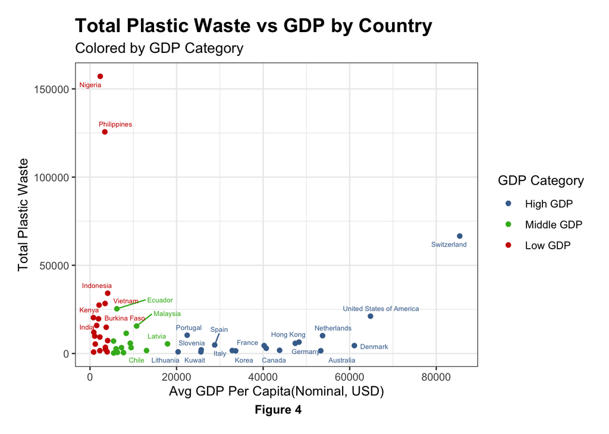

```r
full_summary <- plastics_top |>
  distinct(country) |>
  filter(!country %in% c("EMPTY", "Taiwan_ Republic of China (ROC)", "Nigeria")) |>
  mutate(
    result = map(country, gdp_plastics),
    country = recode(country, "NIGERIA" = "Nigeria", "ECUADOR" = "Ecuador")
  ) |>
  unnest(result) |>
  mutate(gdp_category = case_when(
    is.na(avg_gdp_per_capita_nominal) ~ "Unknown",
    avg_gdp_per_capita_nominal < 5000  ~ "Low GDP",
    avg_gdp_per_capita_nominal < 20000 ~ "Middle GDP",
    avg_gdp_per_capita_nominal >= 20000 ~ "High GDP"
  ))

full_summary |>
  filter(country != "China") |>
  ggplot(aes(x = avg_gdp_per_capita_nominal, y = plastic_total, color = gdp_category)) +
    geom_point(size = 1.5) +
    geom_text_repel(
      aes(label = country),
      size = 2
  ) +
  labs(
    title = "Total Plastic Waste vs GDP by Country",
    subtitle = "Colored by GDP Category",
    x = "Avg GDP Per Capita(Nominal, USD)",
    y = "Total Plastic Waste",
    color = "GDP Category",
    caption = "Figure 4"
  ) +
  scale_color_manual(
  values = c(
    "Low GDP" = "#CD0200",
    "Middle GDP" = "#3CB521",
    "High GDP" = "#446E9B"
  ),
  breaks = c("High GDP", "Middle GDP", "Low GDP")
  ) +
  theme_bw() +
  theme(
    plot.title = element_text(face = "bold", size = 16),
    plot.subtitle = element_text(size = 12),
    plot.margin = margin(15, 15, 15, 15),
    plot.caption.position = "plot",
    plot.caption = element_text(hjust = 0.45,
                                size = 10,
                                face = "bold")
  )
```

Figure 4 manages to refute the assumption that there is a negative relationship present between the average GDP per capita of a country and the plastic waste of that country. From the plot, there is no clear negative relationship present here, but the presence of the outliers explains why Table 4 was indicating the presence of one. It is clear that Nigeria and the Philippines tower over all other countries, inflating the amount of plastic waste for low GDP countries. When those two are disregarded from the analysis, most of the points on the plot are concentrated in the same area for plastic waste, regardless of average GDP per capita.

## Conducting a statistical analysis

A simple linear regression model was used:

$Y_i$ = $\beta_0$ + $\beta_1 X_i$ + $\varepsilon_i$

$Y_i$ = total plastic waste for country $i$

$X_i$ = GDP per capita (nominal) for country $i$

$\beta_0$ = intercept

$\beta_1$ = slope parameter

$\varepsilon_i\sim \text{iid } N(0, \sigma^2)$

```r
model_gdp <- lm(plastic_total ~ avg_gdp_per_capita_nominal, data = full_summary)

tidy(model_gdp) |>
  mutate(term = recode(term,
    "avg_gdp_per_capita_nominal" = "Avg GDP Per Capita (Nominal)"
  )) |>
  gt() |>
  tab_header(
    title = "Linear Regression Results",
    subtitle = "Response: Total Plastic Waste | Predictor: Avg GDP Per Capita (Nominal)"
  ) |>
  tab_caption("Table 5: Regression Model") |>
  tab_style(
    style = cell_text(weight = "bold"),
    locations = list(cells_column_labels(),
                     cells_title())
  ) |>
  cols_label(
    term = "Term",
    estimate = "Estimate",
    std.error = "Std. Error",
    statistic = "t-stat",
    p.value = "p-value"
  ) |>
  fmt_number(
    columns = c(estimate, std.error, statistic),
    decimals = 4
  ) |>
  fmt_number(
    columns = p.value,
    decimals = 4
  )
```

Table 5: Regression Model

Linear Regression Results

Response: Total Plastic Waste | Predictor: Avg GDP Per Capita (Nominal)

| Term | Estimate | Std. Error | t-stat | p-value |
| --- | --- | --- | --- | --- |
| (Intercept) | 16,039.1157 | 5,449.7098 | 2.9431 | 0.0050 |
| Avg GDP Per Capita (Nominal) | −0.0747 | 0.1993 | −0.3747 | 0.7095 |

Table 5, which displays simple regression linear model, examines the relationship between GDP per capita and total plastic waste across countries. This corroborates the findings of Figure 4, as it is apparent that there is no correlation present between these two variables. The estimated slope is -0.0747, barely indicating a very slight negative relationship, and the p-value is 0.7095, which extremely high. This indicates that there is no significant evidence for an association between average GDP per capita and total plastic waste.

Though initial analysis of the relationship between these two predictors would indicate that there was a negative relationship present, in reality there isn’t any apparent trend. Much of what was assumed to be a significant trend came as a result of two outliers skewing the data and the conclusions that could have been made from a surface level analysis between the two variables.

## Looking forward

Though this analysis did not come away with any shocking discoveries about factors that influence plastic pollution, it did come away with some interesting findings on what steps to take in a further exploration of this issue.

Primarily, it did indicate the global presence of corporations has a large impact on plastic pollution. Much of the top 10 polluters had their waste spread across a variety of different countries, rather than containing it to one area, making this a more world wide issue that needs addressing. This indicates that current regulation for plastic waste on the country level alone is not good enough to solve this problem. Because of the global spread of these corporations, there must be international agreements to enact such regulation, rather than on the individual country level.

Additionally, the findings of average GDP per capita not having an effect on the amount of plastic waste a country has challenges the idea that the wealth status of a country has anything to do with its output of plastic waste. Thus, blaming developing countries or wealthy countries for the plastic pollution problem is ultimately extremely unproductive. What is interesting, is the extreme outlier behavior of Nigeria and the Philippines as recipients of such large amounts of waste. Why is it that these two countries are owners of such large amounts of waste compared to the rest of the world? These are questions that must be addressed in the future, by conducting a deeper analysis into this issue.